# Exploration of Factors Affecting Global Rates of Violence against Women

Ingrid Stevens

2022

# 1 Summary & Findings

Violence against women is a common issue in our society, as nearly one-third of all women have experienced some kind of physical violence at some point in their lives. The aim of this report is to answer the following two research questions:

**1. Is there a relation between violence against women and the gender ratio found in primary and secondary classrooms?**

**2. Are countries that experience more violence against women correlated to more babies born per woman?**

# 2 Introduction: Violence Against Women

In this paper, the relationships between violence against women and a few other gender-related factors will be explored. According to the World Health Organization, violence against women is common, as nearly one-third of all women have experienced some kind of physical violence at some point in their lives (Organization 2021). Furthermore, as physical abuse of women by their husbands or partners is unfortunately not uncommon, factors related to family dynamics will be investigated (Sardinha et al. 2022, 3).

The purpose of this paper is to attempt to understand any potential correlation between violence against women and other gender-related factors, such as the ratio of girls to boys in primary and secondary school, and the number of babies per woman on average in a country. Investigating these connections will help the reader determine if there is a correlation between factors present during childhood, such as the gender composition of school peers, and factors impacting the family, such as the number of babies the women in their country have, and violence against women in those countries.

The aim of this report is to answer the following two research questions:

**(1) Is there a relation between classroom composition by gender and gender-based violence in a country?**

**(2) Are countries which experience more violence against women correlated to more babies born per woman?**

# 3 Background

Violence against women has been a persistent and pervasive human rights issue globally. Many women and girls have already or will experience some form of violence or another in their lifetime, and unfortunately the most common form of violence against women is violence from intimate partners (Organization 2009, 3).

Although the role between gender violence and gender is arguably complex, literature suggests that inequality increases the risk of violence by men against women (Organization 2009, 4; Beer 2009; Guedes et al. 2019). With this in mind, this paper will explore inequalities borne from differentiating levels of education attendance for boys and girls, and another potentially related factor, the effect of differences in birth rate between countries on violence against women.

# 4 Methods

To explore this topic, three main variables will be used: Babies per woman, Ratio of girls to boys in primary and secondary education, Violence against women and girls by intimate partners, and Income per person.

First, the data will be cleaned and analyzed. For simplicity, and to ensure data is available for all variables, this paper is limited to only the year 2018. Following that, the data will be explored for correlations and linear relationships. Multivariate relationships will also be explored. Finally, conclusions will be made with regard to the hypotheses, and further research recommendations will be made.

## 4.1 Data

The data used in this paper is from The Gapminder Foundation, which publishes various data sets about the state of the world, a few of which I will use to address this research question.

As the research question explores the relationship between Violence Against Women and the ratio of girls to boys in primary education as well as the number of babies per woman, on average, these hypothetical connections need to be justified. This paper does that in the next section:

### 4.1.1 Justification: Violence against women in relation to school gender ratio

Various studies which have sought to find whether there is a connection between violence and girls accessing schooling, which would indicate that violence against women may cause a change in the ratio of girls and boys attending primary school for fear of violence (Bisika, Ntata, and Konyani 2009, 287). Indeed, in Malawi, a connection between violence against women and girls was found to exist. Therefore, this report will look at gender ratio in primary and secondary education as a possible explanatory variable for violence against women since gender inequality has been distinguished as a risk factor for multiple forms of violence (Willie and Kershaw 2019, 260; Yodanis 2004).

### 4.1.2 Justification: Violence against women in relation to number of babies per woman

Lack of education is often cited as a factor related to increases in violence against women (Adjah and Agbemafle 2016). Similarly, increases in education for women are associated with fewer babies per woman (Mathews and Ventura 1997). Therefore, we might reasonably expect to see a positive correlation between violence against women and babies per woman. This will be explored using data below.

## 4.2 Overview of Variables

Below is an overview of the variables used in this paper. They can be further understood by referencing the included codebook

**Babies per woman:** Average number of babies per woman in a country.

**Ratio of girls to boys in primary and secondary school:** Ratio of girls to boys in primary and secondary education.

**Violence against women and girls by intimate partners:** Ever-partnered women and girls subjected to physical and/or sexual violence by a current or former intimate partner in the previous 12 months (% ages 15–49)

**Income Per Person:** Income per person (GDP/capita, PPP$ inflation adjusted)

## 4.3 Hypothesis

**H0: The violence against women in a country is related to either the ratio of females to males in primary school and/or the babies born per woman.**

**H1: The violence against women in a country is not related to either the ratio of females to males in primary school and/or the babies born per woman.**

# 5 Results

## 5.1 Data Preparation

First, the data sets are read in and cleaned up using pipes to make later organizing easier.

```r
# Create a data set with the three 2018 variables: Violence against women, babies per woman, school ratio

violenceWomen <- read.csv("data/partner_violence.csv") %>%
  rename(violenceWomen2018 = X2018) %>%
  select(country, violenceWomen2018) %>%
  na.omit()

fertilityWomen <- read.csv("data/children_per_woman_total_fertility.csv") %>%
  rename(fertilityWomen2018 = X2018) %>%
  select(country, fertilityWomen2018) %>%
  na.omit()

schoolRatio <- read.csv("data/ratio_of_girls_to_boys_in_primary_and_secondary_education_perc.csv") %>%
  rename(schoolRatio2018 = X2018) %>%
  select(country, schoolRatio2018) %>%
  na.omit()


incomePerPerson <- read.csv("data/income_per_person_gdppercapita_ppp_inflation_adjusted.csv") %>%
  rename(incomePerPerson2018 = X2018) %>%
  select(country, incomePerPerson2018) %>%
  na.omit()
```

Next, we create a dataset called `women_data` with all the relevant data combined for the year 2018.

```r
# Create a data set with the three 2018 variables: Violence against women, babies per woman, school ratio
women_data <- violenceWomen %>%
  left_join(fertilityWomen, by='country') %>%
  left_join(schoolRatio, by='country') %>%
  left_join(incomePerPerson, by='country') %>%
  dplyr::select("country", contains("2018")) %>% # remove all other columns from DF
  na.omit() %>%   # remove rows with NA
  mutate(gender2018 = case_when( # create a new column and display the type of school gender composition
    schoolRatio2018 < 1 ~ "more_boys",
    schoolRatio2018 == 1 ~ "equal",
    schoolRatio2018 > 1 ~ "more_girls",
    TRUE ~ "NA"
  ))
```

## 5.2 Summary Statistics

First, summary statistics are be generated for all variables.

```r
knitr::kable(summary(women_data))
```

|  | country | violenceWomen2018 | fertilityWomen2018 | schoolRatio2018 | incomePerPerson2018 | gender2018 |
| --- | --- | --- | --- | --- | --- | --- |
|  | Length:106 | Min. : 2.000 | Min. :1.230 | Min. :0.7270 | Min. : 0 | Length:106 |
|  | Class :character | 1st Qu.: 4.000 | 1st Qu.:1.593 | 1st Qu.:0.9860 | 1st Qu.: 3860 | Class :character |
|  | Mode :character | Median : 6.000 | Median :1.905 | Median :1.0000 | Median :13300 | Mode :character |
|  | NA | Mean : 8.654 | Mean :2.309 | Mean :0.9972 | Mean :18495 | NA |
|  | NA | 3rd Qu.:11.000 | 3rd Qu.:2.428 | 3rd Qu.:1.0175 | 3rd Qu.:28125 | NA |
|  | NA | Max. :31.000 | Max. :5.880 | Max. :1.1200 | Max. :68200 | NA |

## 5.3 Boxplots & Histograms of Key Variables

To better understand the data, a histogram will be made of the three main variables, plus the fourth variable of income per capita:

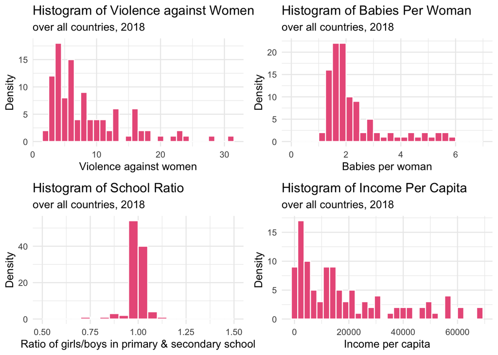

```r
# Placing all four histograms in a grid
grid.arrange(violence_hist, fertility_hist, school_hist, income_hist, ncol=2)
```

**Violence against Women**

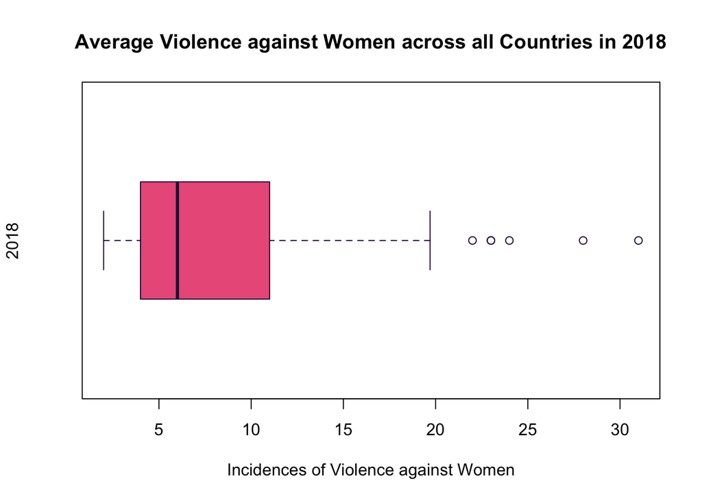

Fig 4.3.1 Boxplot showing violence against women

```r
boxplot(women_data$violenceWomen2018,
  main = "Average Violence against Women across all Countries in 2018",
  xlab = "Incidences of Violence against Women",
  ylab = "2018",
  col = "#EA5F89",
  border = "#2B0B3F",
  horizontal = TRUE,
  notch = FALSE
)
```

**Fertility Rate**

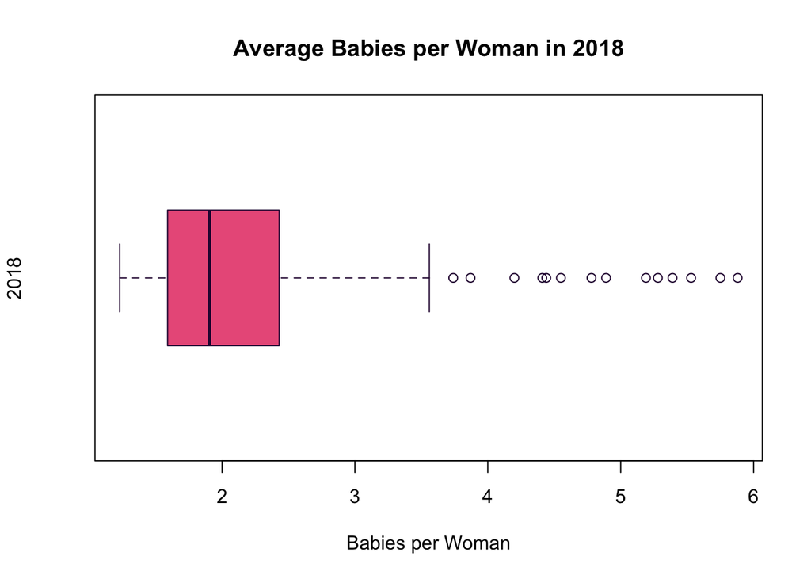

Fig 4.3.2 Boxplot showing average number of babies per woman

```r
boxplot(women_data$fertilityWomen2018,
  main = "Average Babies per Woman in 2018",
  xlab = "Babies per Woman",
  ylab = "2018",
  col = "#EA5F89",
  border = "#2B0B3F",
  horizontal = TRUE,
  notch = FALSE
)
```

**Ratio of Girls to Boys in Primary & Secondary Education**

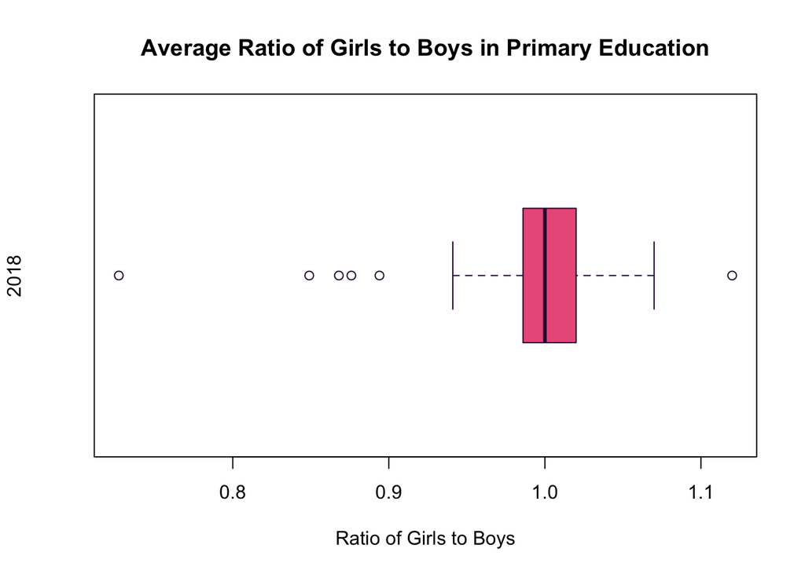

Fig 4.3.3 Boxplot showing ratio of girls to boys in primary school

```r
school_boxplot <- boxplot(women_data$schoolRatio2018,
  main = "Average Ratio of Girls to Boys in Primary Education",
  xlab = "Ratio of Girls to Boys",
  ylab = "2018",
  col = "#EA5F89",
  border = "#2B0B3F",
  horizontal = TRUE,
  notch = FALSE
)
```

## 5.4 Data Analysis

### 5.4.1 Plots

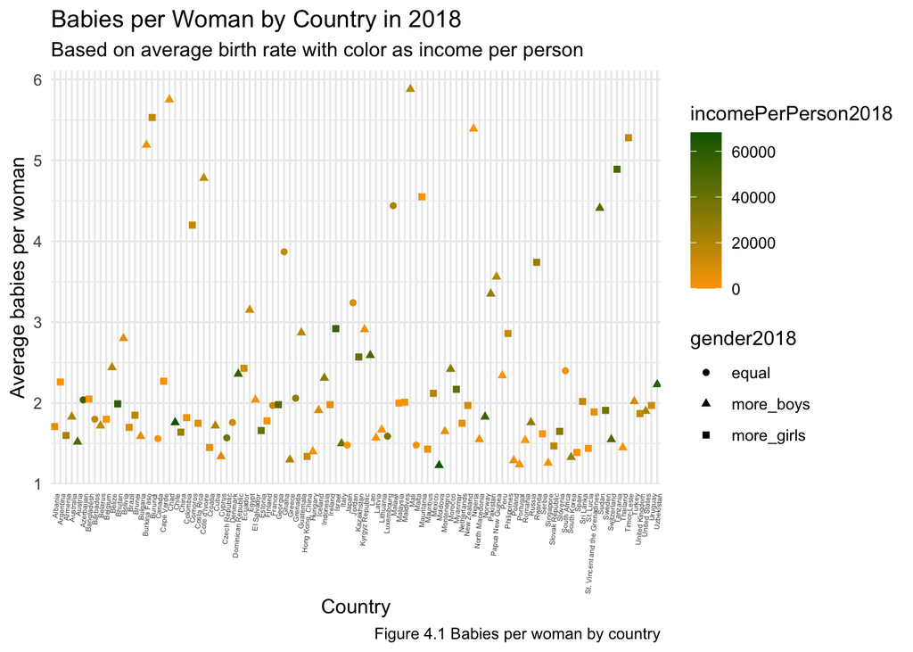

```r
# Plot Data: Babies per woman by country

ggplot(data=women_data, mapping=aes(x=country, y=fertilityWomen2018))+
  geom_point(aes(color = incomePerPerson2018, shape = gender2018)) +
  theme(axis.text.x = element_text(size = .05))+
  scale_color_gradient(low = "orange", high = "darkgreen") +
  theme_minimal() +
  labs(x="Country", y="Average babies per woman",
       title="Babies per Woman by Country in 2018",
       subtitle="Based on average birth rate with color as income per person",
       caption = "Figure 4.1 Babies per woman by country") +
  geom_smooth(formula = y ~ x, method=lm, color="#FFF1C9") +
  scale_x_discrete(guide = guide_axis(angle = 85)) +
  theme(axis.text.x=element_text(size=4))
```

Variations in the gender distribution within primary and secondary schools can be seen by the shape of the datapoints.

Variations in income can be seen by the color variation of the dots.

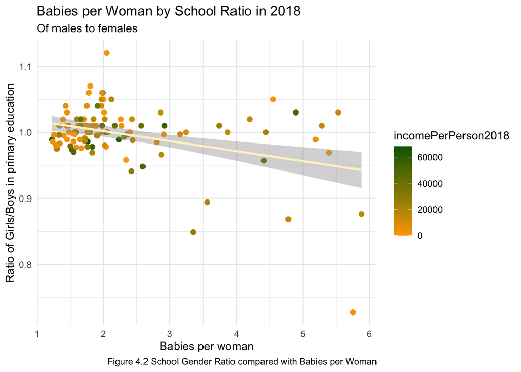

```r
# Plot Data: Babies per woman by ratio of girls to boys in primary school

ggplot(data=women_data, mapping=aes(x=fertilityWomen2018, y=schoolRatio2018))+
  geom_point()+
  theme_minimal() +
  labs(x="Babies per woman", y="Ratio of Girls/Boys in primary education",
       title="Babies per Woman by School Ratio in 2018",
       subtitle="Of males to females ",
       caption = "Figure 4.2 School Gender Ratio compared with Babies per Woman") +
  geom_point(aes(color = incomePerPerson2018), size = 2) +
  scale_color_gradient(low = "orange", high = "darkgreen") +
  geom_smooth(formula = y ~ x, method=lm, color="#FFF1C9")
```

There appears to be a downward trend, where as babies per woman increase, fewer girls are found in primary and secondary education. This may, however, be due to outliers such as Chad, which has a average rate of 5.75 babies per woman and a school gender ratio of 0.727 (more boys than girls in school).

Variations in income can be seen by the color variation of the dots.

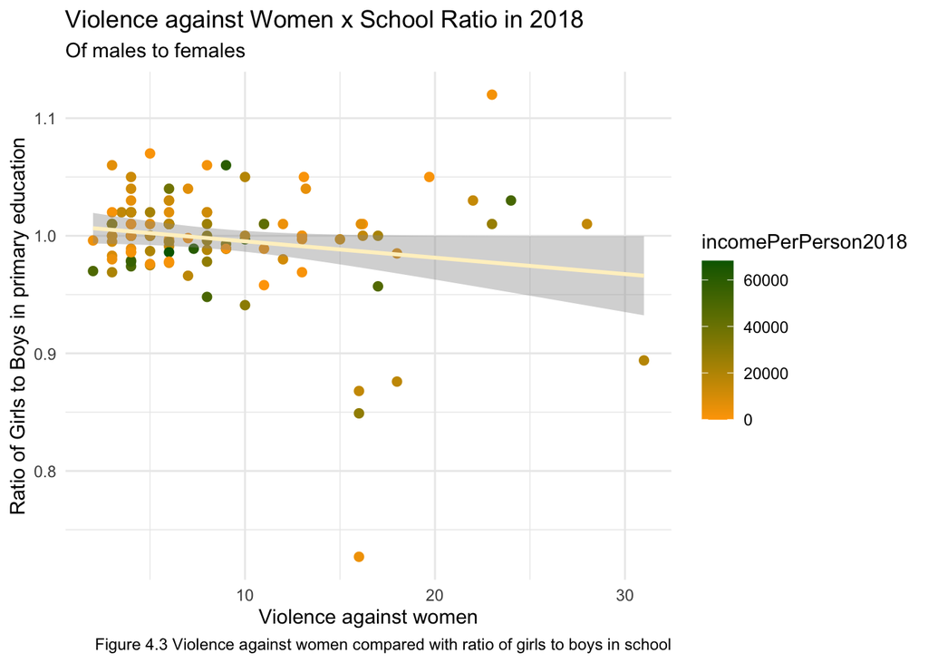

```r
# Plot Data: Violence against Women plotted against Ratio of girls:boys in school

ggplot(data=women_data, mapping=aes(x=violenceWomen2018, y=schoolRatio2018))+
  geom_point()+
  theme_minimal() +
  labs(x="Violence against women",
       y="Ratio of Girls to Boys in primary education",
       title="Violence against Women x School Ratio in 2018",
       subtitle="Of males to females ",
       caption = "Figure 4.3 Violence against women compared with ratio of girls to boys in school") +
  geom_point(aes(color = incomePerPerson2018), size = 2) +
  scale_color_gradient(low = "orange", high = "darkgreen") +
  geom_smooth(formula = y ~ x, method=lm, color="#FFF1C9")
```

As seen in Figure 4.3, there is a slight downward trend where as the ratio of girls to boys in primary education decreases (meaning there are more boys than girls in school), we see higher incidents of violence against women. However, this trend may be present due to a few outliers of very high rates of violence against women (i.e. Papua New Guinea).

Variations in income can be seen by the color variation of the dots.

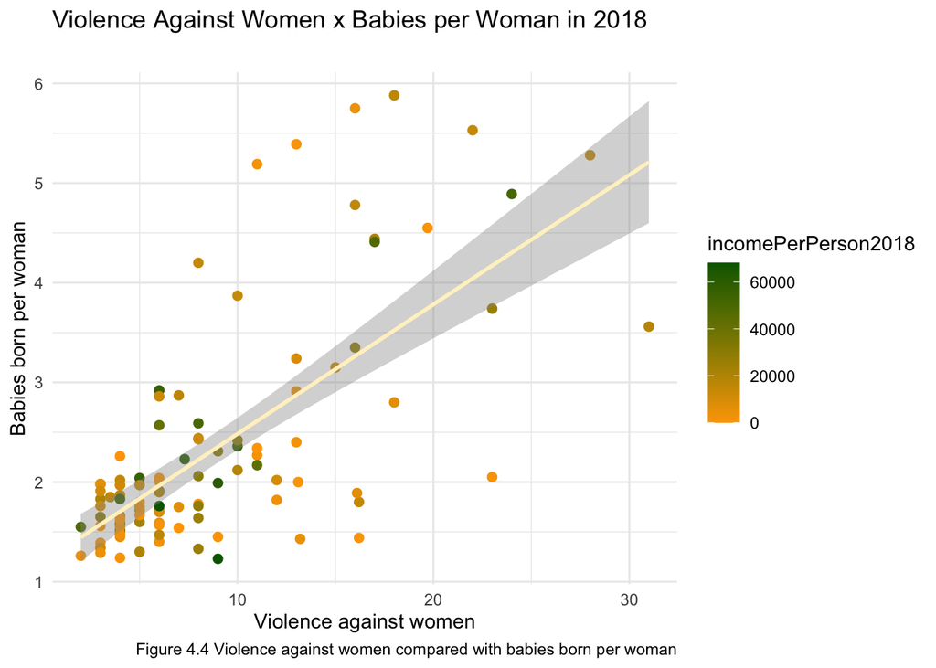

```r
# Plot Data: Violence against Women plotted against Birthrate

ggplot(data=women_data, mapping=aes(x=violenceWomen2018, y=fertilityWomen2018))+
  geom_point()+
  theme_minimal() +
  labs(x="Violence against women",
       y="Babies born per woman",
       title="Violence Against Women x Babies per Woman in 2018",
       subtitle="",
       caption = "Figure 4.4 Violence against women compared with babies born per woman") +
  geom_point(aes(color = incomePerPerson2018), size = 2) +
  scale_color_gradient(low = "orange", high = "darkgreen") +
  geom_smooth(formula = y ~ x, method=lm, color="#FFF1C9")
```

```r
cor(women_data$violenceWomen2018, women_data$fertilityWomen2018)
```

```
## [1] 0.6898598
```

As seen in Figure 4.4, a fairly strong correlation can be seen between babies per woman and violence against women. Calculated, the correlation is 68.98%, meaning that there is a positive, moderately strong correlation between babies per woman and violence against women.

Variations in income can be seen by the color variation of the dots.

### 5.4.2 Linear Regression

As one of the final steps in this paper, a linear regression is conducted to understand the relationship between variables.

```r
# Fit lm() regression:

violence_school <- lm(violenceWomen2018 ~ schoolRatio2018, data = women_data)
birthrate_violence <- lm(fertilityWomen2018 ~ violenceWomen2018, data = women_data)
```

**The tables below show the r-squared values for each combination of the three main variables**

**Violence & School Ratio**

```r
knitr::kable(get_regression_summaries(violence_school))
```

| r_squared | adj_r_squared | mse | rmse | sigma | statistic | p_value | df | nobs |
| --- | --- | --- | --- | --- | --- | --- | --- | --- |
| 0.033 | 0.024 | 34.26176 | 5.853355 | 5.909 | 3.6 | 0.061 | 1 | 106 |

**Babies per Woman & Violence**

```r
knitr::kable(get_regression_summaries(birthrate_violence))
```

| r_squared | adj_r_squared | mse | rmse | sigma | statistic | p_value | df | nobs |
| --- | --- | --- | --- | --- | --- | --- | --- | --- |
| 0.476 | 0.471 | 0.6583943 | 0.811415 | 0.819 | 94.438 | 0 | 1 | 106 |

The r-squared value is a measure of how well a regression model fits the data. The values seen for the r-squared value on each of these combinations of variables indicates that the relation between babies per woman and violence against women is the best fit of all three measured in the section above, as the r-squared value for Babies per Woman and Violence is 0.476. This indicates that only 47.6% of the variation in violence against women can be explained by the number of babies produced by a woman, on average, in a country.

The r-squared value for the relationship between violence against women and the ratio of boys to girls in a school is quite low at 0.033. This means that the ratio of boys to girls in school can only explain 3.3% of the variation in violence against women.

### 5.4.3 Multiple linear regression

Next, multivariate regression will be performed to identify any relationships between both variables (school gender ratio and babies per woman) and violence against women.

```r
gender_model_all <- lm(violenceWomen2018 ~ schoolRatio2018 * fertilityWomen2018, data = women_data)
```

```r
# Get regression summaries:
knitr::kable(get_regression_table(gender_model_all))
```

| term | estimate | std_error | statistic | p_value | lower_ci | upper_ci |
| --- | --- | --- | --- | --- | --- | --- |
| intercept | 0.316 | 25.194 | 0.013 | 0.990 | -49.657 | 50.288 |
| schoolRatio2018 | -0.583 | 25.184 | -0.023 | 0.982 | -50.535 | 49.369 |
| fertilityWomen2018 | 0.748 | 5.825 | 0.128 | 0.898 | -10.807 | 12.302 |
| schoolRatio2018:fertilityWomen2018 | 3.150 | 5.915 | 0.533 | 0.595 | -8.582 | 14.883 |

```r
multiple_lm <- lm(violenceWomen2018 ~ fertilityWomen2018 + schoolRatio2018, data = women_data)
```

**Checking for heteroscedasticity**

As the plot below shows a fairly straight-across horizontal line on the Residuals vs Fitted plot, it seems fine to proceed with the interpretation of the results.

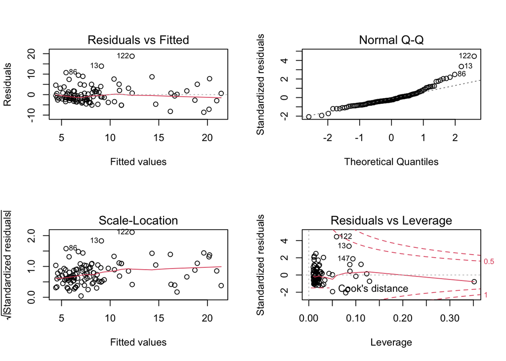

```r
par(mfrow=c(2,2))
plot(multiple_lm)
```

```r
summary(multiple_lm)
```

```
##
## Call:
## lm(formula = violenceWomen2018 ~ fertilityWomen2018 + schoolRatio2018,
##     data = women_data)
##
## Residuals:
##    Min     1Q Median     3Q    Max
## -8.630 -2.580 -1.054  1.546 18.747
##
## Coefficients:
##                    Estimate Std. Error t value Pr(>|t|)
## (Intercept)        -11.8952    10.4085  -1.143    0.256
## fertilityWomen2018   3.8428     0.4063   9.459 1.18e-15 ***
## schoolRatio2018     11.7097    10.0392   1.166    0.246
## ---
## Signif. codes:  0 '***' 0.001 '**' 0.01 '*' 0.05 '.' 0.1 ' ' 1
##
## Residual standard error: 4.344 on 103 degrees of freedom
## Multiple R-squared:  0.4827, Adjusted R-squared:  0.4727
## F-statistic: 48.06 on 2 and 103 DF,  p-value: 1.803e-15
```

As seen from the summary above, the coefficients of babies per women on violence against women is 3.84, while the estimated effect of the ratio of boys to girls in primary and secondary school is 11.71.

This means that for every 1% increase in babies per woman, there is a correlated 3.84% increase in violence against women. Meanwhile, for every 1% increase in the ratio of girls to boys in primary and secondary school, there is a 11.71% increase in the rate of violence against women.

The standard errors for these coefficients are relatively large for babies per woman and school gender ratio (0.41 and 10.04 respectively). Given how large the standard error is for the school gender ratio is, it is best to discard this 11.71% increase we see in the data.

# 6 Discussion

Violence against women is a major public health and human rights problem affecting millions of women and girls worldwide (Organization et al. 2014). Understanding the core elements that lead to violence against women can help to reduce it.

While there are many complex factors that contribute to the prevalence of violence against women, one connection explored in this paper is the relationship between the amount of violence against women and the gender makeup of children in primary and secondary education. This paper found a weak relationship between gender ratio in schools and violence against women. Thereby, we reject the alternative hypothesis, and maintain that there is no significant correlation between violence against women and the gender ratio found in primary and secondary education.

The data collected also showed a correlation between babies per woman and violence against women. **It was revealed that for every 1% increase in the number of babies per woman, there is a 3.84% increase in violence against women.** However, since the number of babies per woman in a country can only explain 47.6% of the variation in violence against women, there are most likely other variables that were not explored in this paper which would explain an increase in violence against women better. We can safely accept the null hypothesis that there is a moderate correlation between violence against women and birth rate.

# 7 Conclusion

To sum up, there is a connection between the incidence of violence against women and the number of babies born per woman rate, but less than half of the variation in violence against women (47.6%) can be explained by the number of babies born per woman. There is a very weak correlation between the ratio of boys to girls in school and the violence against women, with the former only explaining 3.3% of the variation.Thus, we accept the null hypothesis and assess that there is a moderate correlation between at least two of the variables examined.

Based on the data, it is likely that there are other, as of yet unidentified, factors involved. To expand on this work and develop a greater understanding of the factors related to increased levels of violence against women, further research into the proximate causes of violence against women, as well as exploration of the data sources that contribute to this understanding, is warranted.

# References

Adjah, Ebenezer S Owusu, and Isaac Agbemafle. 2016. “Determinants of Domestic Violence Against Women in Ghana.” *BMC Public Health* 16 (1): 1–9.

Beer, Caroline. 2009. “Democracy and Gender Equality.” *Studies in Comparative International Development* 44 (3): 212–27.

Bisika, Thomas, Pierson Ntata, and Sidon Konyani. 2009. “Gender Violence and Education in Malawi: A Study of Violence Against Girls as an Obstruction to Universal Primary School Education.” *Journal of Gender Studies* 18 (3): 287–94.

Guedes, KP, CVN de Souza Junior, GH de M Cunha, et al. 2019. “Determinants of Domestic Violence Against Women.” *Revista Da Universidade Vale Do Rio Verde* 17 (1).

Mathews, TJ, and Stephanie J Ventura. 1997. “Birth and Fertility Rates by Educational Attainment: United States, 1994.”

Organization, World Health. 2005. “Addressing Violence Against Women and Achieving the Millennium Development Goals.”

———. 2009. “Promoting Gender Equality to Prevent Violence Against Women.”

Organization, World Health et al. 2014. “Violence Against Women.”

Organization, World Health. 2021. “Violence Against Women.”

Sardinha, Lynnmarie, Mathieu Maheu-Giroux, Heidi Stöckl, Sarah Rachel Meyer, and Claudia Garcı́a-Moreno. 2022. “Global, Regional, and National Prevalence Estimates of Physical or Sexual, or Both, Intimate Partner Violence Against Women in 2018.” *The Lancet*.

Willie, Tiara C, and Trace S Kershaw. 2019. “An Ecological Analysis of Gender Inequality and Intimate Partner Violence in the United States.” *Preventive Medicine* 118: 257–63.

Yodanis, Carrie L. 2004. “Gender Inequality, Violence Against Women, and Fear a Cross-National Test of the Feminist Theory of Violence Against Women.” *Journal of Interpersonal Violence* 19 (6): 655–75.